# Poynting-Thomson model

Vypracoval: Daniel **BERÁNEK**

Předmět: **132PRPM** - Přetváření a porušování materiálů

**Koeficienty:**

a = 1.2

b = 1.4

c = 0.8

## Zadání

[figure not shown]

Obrázek 1: Reologický model

Reologický model na obrázku vznikl sériovým zapojením pružiny a Kelvinova článku a je charakterizován parametry:

$$ E_0 = (50 + 10a) \, \mathrm{GPa}, \tag{1.0} \label{eq:E_0} $$

$$ E_1 = (40 + 10b) \, \mathrm{GPa}, \tag{2.0} \label{eq:E_1} $$

$$ \eta_1 = (800 + 100c) \, \mathrm{GPa \cdot s}. \tag{2.1} \label{eq:eta_1} $$

Tyto parametry se v čase nemění, jde tedy o model viskoelastického materiálu bez stárnutí.

1. Odvoďte funkci poddajnosti $J_0(t)$ a sestrojte její graf. Pro kontrolu budete potřebovat hodnoty funkce poddajnosti v časech $t = 0, 10, 20$ a $30 \, \mathrm{s}$ a její limitní hodnotu pro čas rostoucí nade všechny meze.
2. Odvoďte relaxační funkci $R_0(t)$ a sestrojte její graf. Pro kontrolu budete potřebovat hodnoty funkce poddajnosti v časech $t = 0, 10, 20$ a $30 \, \mathrm{s}$ a její limitní hodnotu pro čas rostoucí nade všechny meze.
3. Zjistěte, zda vztah $R_0(t)$ = $1 / J_0(t)$ platí pro libovolné $t \geq 0$, nebo jen pro některé hodnoty $t$, nebo pro vůbec žádné.
4. Popište vývoj deformace odpovídající napětí rostoucímu konstantní rychlostí z nulové hodnoty v čase $0$ do hodnoty $8 \, \mathrm{MPa}$ v čase $t_1$. Přitom uvažujte tři různé případy: a) $t_1 = 10 \, \mathrm{s}$, b) $t_1 = 20 \, \mathrm{s}$, c) $t_1 = 40 \, \mathrm{s}$. Pro každý z těchto případů vyneste graf znázorňující vývoj deformace v čase a pracovní diagram znázorňující závislost mezi napětím a deformací. Všechny tři pracovní diagramy vyneste do stejného obrázku a nakreslete do něj také, jak by pracovní diagram vypadal pro extrémně pomalé a extrémně rychlé zatěžování. Pro kontrolu budete potřebovat pro případy a)-c) hodnoty deformace odpovídající napětí $2 \, \mathrm{MPa}, 4 \, \mathrm{MPa}, 6 \, \mathrm{MPa}$ a $8 \, \mathrm{MPa}.$

Napětí v elastickém článku (pružině) je v případě lineárního modelu popsáno Hookeovým zákonem

$$ \sigma_{i,e}(t) = E_i \varepsilon_{i,e}(t), \ i=0,1, \tag{3.0} \label{eq:sigma_pruzina}$$

pro lineární vazký tlumič je přenášené napětí úměrné rychlosti poměrné deformace

$$ \sigma_{1,v}(t) = \eta_1 \dot{\varepsilon}_{1,v}(t). \tag{3.1} \label{eq:sigma_tlumic} $$

Při paralelním zapojení pružiny a tlumiče, které označujeme jako Kelvinův čánek, jsou oba články podrobeny stejné deformaci a celkové napětí je součtem příspěvků pružného a vazkého článku. Formálně to lze popsat vztahy

$$ \varepsilon_1(t) = \varepsilon_{1,e}(t) = \varepsilon_{1,v}(t), \tag{4.0} \label{eq:epsilon_kelvin} $$ $$ \sigma_1(t) = \sigma_{1,e}(t) + \sigma_{1,v}(t). \tag{4.1} \label{eq:sigma_kelvin} $$

Poynting-Thompson model na obr. 1 je složen z jedné pružiny a jednoho Kelvinova článku. Vzhledem k sériovému zapojení jednotek je celková poměrná deformace

$$ \varepsilon(t) = \varepsilon_0(t) + \varepsilon_1(t). \tag{5.0} \label{eq:epsilon} $$

Je zřejmé, že každá jednotka přenáší stejné celkové napětí $\sigma(t)$. Podmínky rovnováhy lze zapsat pro každou jednotku zvlášť ve tvaru

$$ \sigma(t) = \sigma_{0,e}(t), \tag{6.0} \label{eq:sigma_0} $$ $$ \sigma(t) = \sigma_{1,e}(t) + \sigma_{1,v}(t). \tag{6.1} \label{eq:sigma_1} $$

Po dosazení vztahů \eqref{eq:sigma_pruzina} a \eqref{eq:sigma_tlumic} do vztahu \eqref{eq:sigma_0} a \eqref{eq:sigma_1} dostaneme soustavu dvou navzájem nezávislých rovnic

$$ \sigma(t) = E_0 \varepsilon_{0,e}(t) \tag{7.0} \label{eq:sigma_0_dosazena}$$ $$ \sigma(t) = E_{1}\varepsilon_{1,e}(t) + \eta_{1} \dot{\varepsilon}_{1,v}(t). \tag{7.1} \label{eq:sigma_1_dosazena}$$

Ve vztahu \eqref{eq:sigma_0_dosazena} není nutné psát dolní index $e$, protože v pružině dochází pouze k elastické deformaci $$ \sigma(t) = E_0 \varepsilon_{0}(t), \tag{8.0} \label{eq:sigma_0_dosazena_zjednodusena}$$

vztah \eqref{eq:sigma_1_dosazena} lze na základě vztahu \eqref{eq:epsilon_kelvin} zjednodušit na

$$ \sigma(t) = E_{1}\varepsilon_{1}(t) + \eta_{1} \dot{\varepsilon}_{1}(t). \tag{8.1} \label{eq:sigma_1_dosazena_zjednodusena}$$

Derivaci výrazu \eqref{eq:sigma_0_dosazena_zjednodusena} podle času lze zapsat jako

$$ \dot{\sigma}(t) = E_0 \dot{\varepsilon}_{0}(t). \tag{9.0} \label{eq:dsigma}$$

Vyjádřením $\varepsilon_1(t)$ ze vztahu \eqref{eq:epsilon} dostaneme

$$ \varepsilon_1(t) = \varepsilon(t) - \varepsilon_0(t), \tag{10.0} \label{eq:epsilon_1}$$

stejný vztah platí pro derivaci

$$ \dot{\varepsilon}_1(t) = \dot{\varepsilon}(t) - \dot{\varepsilon}_0(t). \tag{11.0} \label{eq:depsilon_1}$$

Dosazením výrazů \eqref{eq:epsilon_1} a \eqref{eq:depsilon_1} do rovnice \eqref{eq:sigma_1_dosazena_zjednodusena} dostaneme

$$ \sigma(t) = E_{1}(\varepsilon(t) - \varepsilon_0(t)) + \eta_{1} (\dot{\varepsilon}(t) - \dot{\varepsilon}_0(t)). \tag{12.0} \label{eq:sigma_1_nevimuz}$$

Rovnici lze dále upravit dosazením za $\varepsilon_0(t)$ z rovnice \eqref{eq:sigma_0_dosazena_zjednodusena} a za $\dot{\varepsilon}_0(t)$ ze vztahu \eqref{eq:dsigma}

$$ \sigma(t) = E_1 \left( \varepsilon(t) - \frac{\sigma(t)}{E_0} \right) + \eta_1 \left( \dot{\varepsilon}(t) - \frac{\dot{\sigma}(t)}{E_0} \right). \tag {13.0} \label{eq:sigma_dosazeno} $$

Roznásobením závorek a úpravami dostaneme vztah

$$ E_1 \varepsilon(t) + \eta_1 \dot{\varepsilon}(t) = \frac{E_0 + E_1}{E_0} \sigma(t) + \frac{\eta_1}{E_0} \dot{\sigma}(t) \tag {14.0} \label{eq:dif_rce} $$

## Odvození funkce poddajnosti

Model zatížíme od času $t=0\,\mathrm{s}$ konstantním napětím $\sigma(t) = \hat\sigma H(t)$, kde $H(t)$ je Heavisideova funkce daná předpisem

$$H(t) = \left\{ \begin{matrix} 0 \quad & \mathrm{pro} \ t < 0, \\ 1 \quad & \mathrm{pro} \ t \geq 0. \end{matrix} \right. \tag{15.0} \label{eq:Heaviside} $$

Protože $\hat{\sigma} H(t)$ je konstantní funkce, pro její derivaci platí

$$ \hat{\sigma} \dot{H}(t) = 0. \tag{16.0} \label{eq:derivace_sigma_se_striskou} $$

Dosazením do vztahu \eqref{eq:dif_rce} dostaneme

$$ E_1 \varepsilon(t) + \eta_1 \dot{\varepsilon}(t) = \frac{E_0 + E_1}{E_0} \hat{\sigma}H(t). \tag {17.0} \label{eq:dif_rce_1} $$

Rovnice \eqref{eq:dif_rce_1} je nehomogenní lineární diferenciální rovnice 1. řádu s konstantními koeficienty.

Postup řešení lineární diferenciální rovnice 1. řádu se skládá ze dvou kroků:

1. **Řešení příslušné homogenní rovnice:** Příslušnou homogenní lineární rovnici lze vyřešit separací proměnných. V jejím řešení se vyskytuje konstanta, označená $C$.
2. **Metoda variace konstanty:** Konstantu $C$ v řešení příslušné homogenní rovnice z kroku 1 považujeme za funkci proměnné $t$, tj. $$C = C(t)$$ a toto řešení (s $C(t)$ místo $C$ dosadíme do původní nehomogenní rovnice. Vznikne rovnice s jednou neznámou a to $C'=C'(t)$. Určíme $C'=C'(t)$ a integrací vypočítáme $C=C(t)$. Po dosazení za $C=C(t)$ dostaneme výsledné řešení.

Rovnici \eqref{eq:dif_rce_1} převedeme na tvar

$$ \dot{\varepsilon}(t) + \frac{E_1}{\eta_1} \varepsilon(t) = \frac{E_0 + E_1}{E_0 \eta_1} \hat{\sigma}H(t). \tag {18.0} \label{eq:nehomogenni_dif_rce} $$

Řešení \eqref{eq:nehomogenni_dif_rce} budeme hledat ve tvaru

$$ \varepsilon(t) = C(t) \varepsilon_h(t), \tag{19.0} \label{eq:predpokladany_tvar_reseni}$$

kde $C(t)$ je hledaná funkce proměnné $t$ a $\varepsilon_h(t)$ je řešení homogenní rovnice

$$ \dot{\varepsilon}(t) + \frac{E_1}{\eta_1} \varepsilon(t) = 0. \tag {20.0} \label{eq:homogenni_dif_rce} $$

Funkci $\varepsilon_{h}(t)$ budeme hledat ve tvaru

$$ \varepsilon_{h}(t) = C \exp{(\lambda t)}, \tag{21.0} \label{eq:tvar_reseni_epsilon}$$

kde $C$ a $\lambda$ jsou zatím neurčené konstanty.

Derivaci rovnice \eqref{eq:tvar_reseni_epsilon} lze zapsat jako

$$ \dot{\varepsilon}_{h}(t) = C \lambda \exp{(\lambda t)}. \tag{22.0} \label{eq:tvar_reseni_depsilon}$$

Dosazení vztahů \eqref{eq:tvar_reseni_epsilon} a \eqref{eq:tvar_reseni_depsilon} do \eqref{eq:homogenni_dif_rce} dostaneme

$$ C \lambda \exp{(\lambda t)} + \frac{E_1}{\eta_{1}} C \exp{(\lambda t)} = 0. \tag{23.0} \label{eq:dosazeni_homo_rce} $$

Úpravou vztahu \eqref{eq:dosazeni_homo_rce} lze přejít ke tvaru

$$ C \exp{(\lambda t)} \left( \lambda + \frac{E_1}{\eta_1} \right) = 0, \tag{24.0} \label{eq:homo_rce_uprava}$$

který je splněn právě tehdy, když platí

$$ \lambda + \frac{E_1}{\eta_1} = 0. \tag{25.0} \label{eq:charakteristicka_rovnice} $$

Z této charakteristické rovnice lze vypočítat konstantu

$$ \lambda = - \frac{E_1}{\eta_1} \tag{26.0} \label{eq:lambda}. $$

Homogenní řešení má tedy tvar

$$ \varepsilon_{h}(t) = C \exp{\left(-\frac{E_1}{\eta_1}t\right)}, \tag{27.0} \label{eq:reseni_homo}$$

Položíme $C=C(t)$ a dosadíme do rovnice \eqref{eq:predpokladany_tvar_reseni}

$$ \varepsilon(t) = C(t) \exp{\left(-\frac{E_1}{\eta_1}t\right)}, \tag{28.0} \label{eq:28}$$

zderivováním výrazu dostaneme vztah

$$ \dot{\varepsilon}(t) = \dot{C}(t) \exp{\left(-\frac{E_1}{\eta_1}t\right)} - C(t)\frac{E_1}{\eta_1}\exp{\left(-\frac{E_1}{\eta_1}t\right)}. \tag{29.0} \label{eq:derivace_epsilon} $$

Dosazením za $\varepsilon(t)$ a $\dot{\varepsilon}(t)$ do původní nehomogenní rovnice \eqref{eq:nehomogenni_dif_rce} dostaneme vztah

$$ \dot{C}(t) \exp{\left(-\frac{E_1}{\eta_1}t\right)} - C(t)\frac{E_1}{\eta_1}\exp{\left(-\frac{E_1}{\eta_1}t\right)} + \frac{E_1}{\eta_1}C(t)\exp{\left(-\frac{E_1}{\eta_1}t\right)} = \frac{E_0 + E_1}{E_0 \eta_1} \hat{\sigma}H(t), \tag{30.0} \label{eq:30} $$

ve kterém se oba stejné členy obsahují $C(t)$ odečtou. Dostaneme tedy rovnici

$$ \dot{C}(t) \exp{\left(-\frac{E_1}{\eta_1}t\right)} = \frac{E_0 + E_1}{E_0 \eta_1} \hat{\sigma}H(t), \tag{31.0} \label{eq:31} $$

kterou upravíme na tvar

$$ \dot{C}(t) = \frac{E_0 + E_1}{E_0 \eta_1} \hat{\sigma}H(t) \frac{1}{\exp{\left(-\frac{E_1}{\eta_1}t\right)}}, \tag{32.0} \label{eq:32} $$

a dále ještě můžeme převést $\exp{\left(-\frac{E_1}{\eta_1}t\right)}$ z jmenovatele do čitatele

$$ \dot{C}(t) = \frac{E_0 + E_1}{E_0 \eta_1} \hat{\sigma}H(t) \exp{\left(\frac{E_1}{\eta_1}t\right)}. \tag{33.0} \label{eq:33} $$

Integrací obou stran rovnice \eqref{eq:33} obdržíme

$$ C(t) = \int{\frac{E_0 + E_1}{E_0 \eta_1} \hat{\sigma}H(t) \exp{\left(\frac{E_1}{\eta_1}t\right)}} \mathrm{d}t. \tag{34.0} \label{eq:34} $$

Po vytknutí konstant před integrál dostaneme

$$ C(t) = \frac{E_0 + E_1}{E_0 \eta_1} \hat{\sigma}H(t) \int{\exp{\left(\frac{E_1}{\eta_1}t\right)}} \mathrm{d}t. \tag{35.0} \label{eq:35} $$

Po integraci dostaneme vztah

$$ C(t) = \frac{E_0 + E_1}{E_0 \eta_1} \hat{\sigma}H(t) \frac{\eta_1}{E_1} \exp{\left(\frac{E_1}{\eta_1}t\right)} + A, \tag{36.0} \label{eq:C} $$

Který lze dále zjednodušit

$$ C(t) = \frac{E_0 + E_1}{E_0 E_1} \hat{\sigma}H(t) \exp{\left(\frac{E_1}{\eta_1}t\right)} + A, \tag{37.0} \label{eq:C_zjednodusene} $$

kde $A$ je neznámá konstanta, kterou lze určit z počáteční podmínky

$$ \varepsilon(0) = \frac{\hat{\sigma}H(t)}{E_0}. \tag{38.0} \label{eq:pocatecni_podminka} $$

Dosazením $\varepsilon_h(t)$ z rovnice \eqref{eq:reseni_homo} a $C(t)$ z rovnice \eqref{eq:C_zjednodusene} do vztahu \eqref{eq:predpokladany_tvar_reseni} získáme

$$ \varepsilon(t) = \left[ \frac{E_0 + E_1}{E_0 E_1} \exp{\left(\frac{E_1}{\eta_1}t\right)} \hat{\sigma} H(t) + A \right] \exp{\left(-\frac{E_1}{\eta_1}t\right)}, \tag{39.0} \label{eq:39} $$

kterou lze dále upravit

$$ \varepsilon(t) = \frac{E_0 + E_1}{E_0 E_1} \hat{\sigma} H(t) + A \exp{\left(-\frac{E_1}{\eta_1}t\right)}. \tag{40.0} \label{eq:40} $$

Z počáteční podmínky \eqref{eq:pocatecni_podminka} vyplývá

$$ \frac{E_0 + E_1}{E_0 E_1} \hat{\sigma} H(t) + A \exp{\left(0\right)} = \frac{\hat{\sigma}H(t)}{E_0}. \tag{41.0} \label{eq:41} $$

Úpravami lze vyřešit hodnotu konstanty $A$

$$ A = \frac{\hat{\sigma}H(t)}{E_0} - \frac{E_0 + E_1}{E_0 E_1} \hat{\sigma} H(t), \tag{41.1} $$

$$ A = \frac{\hat{\sigma} H(t) (E_1 - E_0 - E_1)}{E_0 E_1}, \tag{41.2} $$

$$ A = \frac{- \hat{\sigma} H(t) E_0}{E_0 E_1}, \tag{41.3} $$

$$ A = \frac{- \hat{\sigma} H(t)}{E_1}. \tag{41.4} \label{eq:A} $$

Dosazením do vztahu \eqref{eq:40} dostaneme

$$ \varepsilon(t) = \frac{E_0 + E_1}{E_0 E_1} \hat{\sigma} H(t) - \frac{\hat{\sigma} H(t)}{E_1} \exp{\left(-\frac{E_1}{\eta_1}t\right)}. \tag{42.0} $$

Převedením na společného jmenovatele

$$ \varepsilon(t) = \hat{\sigma} H(t) \frac{E_1 + E_0 - E_0 \exp{\left(-\frac{E_1}{\eta_1}t\right)}}{E_0 E_1}, \tag{42.1} $$

a úpravou dostaneme finální vztah pro poměrnou deformaci Poyting-Thomsonova modelu při zatěžovací zkoušce

$$ \varepsilon(t) = \frac{\hat{\sigma} H(t)}{E_0} + \frac{\hat{\sigma} H(t)}{E_1} \left[ 1 - \exp{\left(-\frac{E_1}{\eta_1}t\right)} \right]. \tag{42.2} \label{eq:42_2} $$

Zavedením retardačního času

$$ \tau_1 = \frac{\eta_1}{E_1}, \tag{43.0} \label{eq:retardacni_cas}$$

dojde ke zjednodušení vztahu \eqref{eq:42_2} na

$$ \varepsilon(t) = \left( \frac{1}{E_0} + \frac{1}{E_1} \left[1 - \exp{\left(-\frac{t}{\tau_1}\right)} \right] \right) \hat{\sigma} H(t). \tag{44.0} \label{eq:epsilon_zatezovaci_zkouska} $$

Funkce poddajnosti má tedy tvar

$$ J_0(t) = \left( \frac{1}{E_0} + \frac{1}{E_1} \left[1 - \exp{\left(-\frac{t}{\tau_1}\right)} \right] \right) H(t). \tag{45.0} \label{eq:funkce_poddajnosti} $$

```python
import numpy as np
import matplotlib.pyplot as plt
from IPython.display import display, Math
```

```python
# koeficienty
a = 1.2
b = 1.4
c = 0.8
```

```python
E_0 = (50 + 10*a) # tuhost pruziny 0 (GPa)
E_1 = (40 + 10*b)  # tuhost pruziny 1 (GPa)
ETA_1 = (800 + 100*c) # viskozita tlumice (GPa s)

TAU_1 = ETA_1 / E_1  # retardacni cas (s)
```

```python
def calculate_J_0(time: int | float | np.ndarray) -> int | float | np.ndarray:
    return (1/E_0 + 1/E_1 * (1 - np.exp(-time/TAU_1))) * calculate_heaviside(time)

def calculate_heaviside(time: int | float | np.ndarray) -> int | float | np.ndarray:
    if isinstance(time, np.ndarray):
        heaviside = np.zeros(time.shape)
        heaviside[time >= 0] = 1
        return heaviside
    else:
        if time >= 0:
            return 1
        else:
            return 0
```

```python
t = np.linspace(-10, 150, 1000)
J_0 = calculate_J_0(t) * 10**3
H = calculate_heaviside(t)

times_of_interest = np.array([0, 10, 20, 30, np.inf])
J_0_of_interest = calculate_J_0(times_of_interest) * 10**3
```

```python
for time, compliance in zip(times_of_interest, J_0_of_interest):
    str = "J_0(t=" + f"{time:.0f}" + "\, \mathrm{s}) = " + f"{compliance:.2f}" + " \, \cdot 10^{-12} / \mathrm{Pa}"
    display(Math(str))
```

$\displaystyle J_0(t=0\, \mathrm{s}) = 16.13 \, \cdot 10^{-12} / \mathrm{Pa}$

$\displaystyle J_0(t=10\, \mathrm{s}) = 24.62 \, \cdot 10^{-12} / \mathrm{Pa}$

$\displaystyle J_0(t=20\, \mathrm{s}) = 29.22 \, \cdot 10^{-12} / \mathrm{Pa}$

$\displaystyle J_0(t=30\, \mathrm{s}) = 31.71 \, \cdot 10^{-12} / \mathrm{Pa}$

$\displaystyle J_0(t=inf\, \mathrm{s}) = 34.65 \, \cdot 10^{-12} / \mathrm{Pa}$

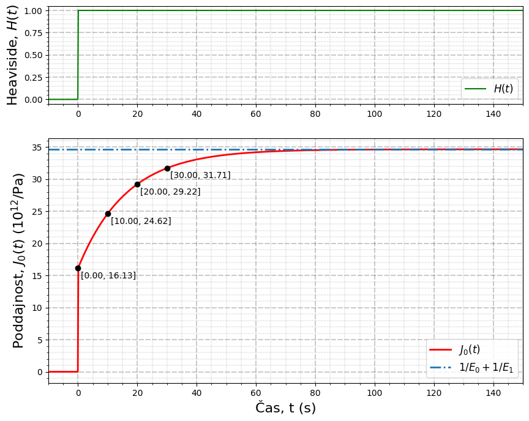

```python
def plot_point_of_interest(x, y, axes, dx, dy, ha, va):
    axes.plot(x, y, 'ko')
    label = f"[{x:.2f}, {y:.2f}]"
    axes.text(x+dx, y+dy, label, ha=ha, va=va)

fig, axs = plt.subplots(2, 1, figsize=(10,8), gridspec_kw={'height_ratios': [1, 2.5]})

axs[0].plot(t, H, 'g', label='$H(t)$')
axs[0].set_ylabel('Heaviside, $H(t)$', fontsize=16)

axs[1].plot(t, J_0, 'r', lw=2, label='$J_0(t)$')
axs[1].axhline(J_0_of_interest[-1], lw=2, ls='-.', label='$1/E_0 + 1/E_1$')
axs[1].set_ylabel('Poddajnost, $J_0(t)$ ($10^{12}$/Pa)', fontsize=16)
axs[1].set_xlabel('Čas, t (s)', fontsize=16)

for time, compliance in zip(times_of_interest[:-1], J_0_of_interest[:-1]):
    plot_point_of_interest(time, compliance, axs[1], 1, -0.5, 'left', 'top')

for i in [0, 1]:
    axs[i].grid(which="major", linestyle=(10, (20, 6)), color='black', lw=0.3)
    axs[i].minorticks_on()
    axs[i].grid(which="minor", linestyle=(0, (1, 3)), color='black', lw=0.3)
    axs[i].legend(loc="lower right", fontsize=12)
    axs[i].set_xlim(t.min(), t.max())

plt.show()
```

## Odvození relaxační funkce

Model zatížíme od času $t=0\,\mathrm{s}$ konstantním přetvořením $\varepsilon(t) = \hat\varepsilon H(t)$, kde $H(t)$ je Heavisideova funkce viz \eqref{eq:Heaviside}.

Protože $\hat\varepsilon H(t)$ je konstantní funkce, pro její derivaci platí

$$ \hat{\varepsilon} \dot{H}(t) = 0. \tag{46.0} \label{eq:derivace_epsilon_se_striskou} $$

Dosazením do vztahu \eqref{eq:dif_rce} dostaneme

$$ E_1 \hat{\varepsilon}(t) H(t) = \frac{E_0 + E_1}{E_0} {\sigma}H(t) + \frac{\eta_1}{E_0} \dot{\sigma}(t). \tag {47.0} \label{eq:dif_rce_47} $$

Rovnice \eqref{eq:dif_rce_47} je nehomogenní lineární diferenciální rovnice 1. řádu s konstantními koeficienty, postup je stejný jako při odvozování funkce poddajnosti $J_0(t).$

Rovnici \eqref{eq:dif_rce_47} převedeme na tvar

$$ \dot{\sigma}(t) + \frac{E_0 + E_1}{\eta_1} \sigma(t) = \frac{E_0 E_1}{\eta_1} \hat{\varepsilon}H(t). \tag {48.0} \label{eq:nehomogenni_dif_rce_sigma} $$

Řešení \eqref{eq:nehomogenni_dif_rce_sigma} budeme hledat ve tvaru

$$ \sigma(t) = C(t) \sigma_h(t), \tag{49.0} \label{eq:predpokladany_tvar_reseni_sigma}$$

kde $C(t)$ je hledaná funkce proměnné $t$ a $\sigma_h(t)$ je řešení homogenní rovnice

$$ \dot{\sigma}_h(t) + \frac{E_0 + E_1}{\eta_1} \sigma_h(t) = 0. \tag {50.0} \label{eq:homogenni_dif_rce_sigma} $$

Funkci $\sigma_{h}(t)$ budeme hledat ve tvaru

$$ \sigma_{h}(t) = C \exp{(\lambda t)}, \tag{51.0} \label{eq:tvar_reseni_sigma}$$

kde $C$ a $\lambda$ jsou zatím neurčené konstanty.

Derivaci rovnice \eqref{eq:tvar_reseni_sigma} lze zapsat jako

$$ \dot{\sigma}_{h}(t) = C \lambda \exp{(\lambda t)}. \tag{52.0} \label{eq:tvar_reseni_dsigma}$$

Dosazení vztahů \eqref{eq:tvar_reseni_sigma} a \eqref{eq:tvar_reseni_dsigma} do \eqref{eq:homogenni_dif_rce_sigma} dostaneme

$$ C \lambda \exp{(\lambda t)} + \frac{E_0+E_1}{\eta_1} C \exp{(\lambda t)} = 0. \tag{53.0} \label{eq:dosazeni_homo_rce_sigma} $$

Úpravou vztahu \eqref{eq:dosazeni_homo_rce_sigma} lze přejít ke tvaru

$$ C \exp{(\lambda t)} \left( \lambda + \frac{E_0+E_1}{\eta_1} \right) = 0, \tag{54.0} \label{eq:homo_rce_uprava_sigma}$$

který je splněn právě tehdy, když platí

$$ \lambda + \frac{E_0+E_1}{\eta_1} = 0. \tag{55.0} \label{eq:charakteristicka_rovnice_sigma} $$

Z této charakteristické rovnice lze vypočítat konstantu

$$ \lambda = - \frac{E_0+E_1}{\eta_1} \tag{56.0} \label{eq:lambda_sigma}. $$

Homogenní řešení má tedy tvar

$$ \sigma_{h}(t) = C \exp{\left(- \frac{E_0+E_1}{\eta_1} t \right)}, \tag{57.0} \label{eq:reseni_homo_sigma}$$

Položíme $C=C(t)$ a dosadíme do rovnice \eqref{eq:predpokladany_tvar_reseni_sigma}

$$ \sigma(t) = C(t) \exp{\left(- \frac{E_0+E_1}{\eta_1} t \right)}, \tag{58.0} \label{eq:58}$$

zderivováním výrazu dostaneme vztah

$$ \dot{\sigma}(t) = \dot{C}(t) \exp{\left(- \frac{E_0+E_1}{\eta_1} t \right)} - C(t)\frac{E_0+E_1}{\eta_1}\exp{\left(- \frac{E_0+E_1}{\eta_1} t \right)}. \tag{59.0} \label{eq:derivace_sigma} $$

Dosazením za $\sigma(t)$ a $\dot{\sigma}(t)$ do původní nehomogenní rovnice \eqref{eq:nehomogenni_dif_rce_sigma} dostaneme vztah

$$ \dot{C}(t) \exp{\left(- \frac{E_0+E_1}{\eta_1} t \right)} - C(t)\frac{E_0+E_1}{\eta_1}\exp{\left(- \frac{E_0+E_1}{\eta_1} t \right)} + C(t)\frac{E_0+E_1}{\eta_1}\exp{\left(- \frac{E_0+E_1}{\eta_1} t \right)} = \frac{E_0 E_1}{\eta_1} \hat{\varepsilon}H(t) \tag{60.0} \label{eq:60} $$

ve kterém se oba stejné členy obsahují $C(t)$ odečtou. Dostaneme tedy rovnici

$$ \dot{C}(t) \exp{\left(- \frac{E_0+E_1}{\eta_1} t \right)} = \frac{E_0 E_1}{\eta_1} \hat{\varepsilon}H(t), \tag{61.0} \label{eq:61} $$

kterou upravíme na tvar

$$ \dot{C}(t) = \frac{E_0 E_1}{\eta_1 \exp{\left(- \frac{E_0+E_1}{\eta_1} t \right)}} \hat{\varepsilon}H(t), \tag{62.0} \label{eq:62} $$

a dále ještě můžeme převést $\exp{\left(- \frac{E_0+E_1}{\eta_1} t \right)}$ z jmenovatele do čitatele

$$ \dot{C}(t) = \frac{E_0 E_1}{\eta_1} \exp{\left(\frac{E_0+E_1}{\eta_1} t \right)} \hat{\varepsilon}H(t). \tag{63.0} \label{eq:63} $$

Integrací obou stran rovnice \eqref{eq:63} obdržíme

$$ C(t) = \int{\frac{E_0 E_1}{\eta_1} \exp{\left(\frac{E_0+E_1}{\eta_1} t \right)} \hat{\varepsilon}H(t)} \mathrm{d}t. \tag{64.0} \label{eq:64} $$

Po vytknutí konstant před integrál dostaneme

$$ C(t) = \frac{E_0 E_1}{\eta_1} \hat{\varepsilon}H(t) \int{ \exp{\left(\frac{E_0+E_1}{\eta_1} t \right)}} \mathrm{d}t. \tag{65.0} \label{eq:65} $$

Po integraci dostaneme vztah

$$ C(t) = \frac{E_0 E_1}{\eta_1} \hat{\varepsilon}H(t) \frac{\eta_1}{E_0+E_1} \exp{\left(\frac{E_0+E_1}{\eta_1} t \right)} + A, \tag{66.0} \label{eq:C_sigma} $$

který lze dále zjednodušit

$$ C(t) = \frac{E_0 E_1}{E_0+E_1} \hat{\varepsilon}H(t) \exp{\left(\frac{E_0+E_1}{\eta_1} t \right)} + A, \tag{67.0} \label{eq:C_sigma_zjednodusene} $$

kde $A$ je neznámá konstanta, kterou lze určit z počáteční podmínky

$$ \sigma(0) = E_0 \hat{\varepsilon}H(t). \tag{68.0} \label{eq:pocatecni_podminka_sigma} $$

Dosazením $\sigma_h(t)$ z rovnice \eqref{eq:reseni_homo_sigma} a $C(t)$ z rovnice \eqref{eq:C_sigma_zjednodusene} do vztahu \eqref{eq:predpokladany_tvar_reseni_sigma} získáme

$$ \sigma(t) = \left[ \frac{E_0 E_1}{E_0+E_1} \hat{\varepsilon}H(t) \exp{\left(\frac{E_0+E_1}{\eta_1} t \right)} + A \right] \exp{\left(-\frac{E_0+E_1}{\eta_1}t\right)}, \tag{69.0} \label{eq:69} $$

kterou lze dále upravit

$$ \sigma(t) = \frac{E_0 E_1}{E_0+E_1} \hat{\varepsilon}H(t) + A \exp{\left(-\frac{E_0+E_1}{\eta_1}t\right)}. \tag{70.0} \label{eq:70} $$

Z počáteční podmínky \eqref{eq:pocatecni_podminka_sigma} vyplývá

$$ E_0 \hat{\varepsilon}H(t) = \frac{E_0 E_1}{E_0+E_1} \hat{\varepsilon}H(t) + A \exp{\left(0\right)}. \tag{81.0} \label{eq:81} $$

Úpravami lze vyřešit hodnotu konstanty $A$

$$ A = E_0 \hat{\varepsilon}H(t) - \frac{E_0 E_1}{E_0+E_1} \hat{\varepsilon}H(t), \tag{71.1} $$

$$ A = \hat{\varepsilon}H(t) \left( E_0 - \frac{E_0 E_1}{E_0+E_1} \right), \tag{71.2} $$

Dosazením do vztahu \eqref{eq:70} dostaneme

$$ \sigma(t) = \frac{E_0 E_1}{E_0+E_1} \hat{\varepsilon}H(t) + \hat{\varepsilon}H(t) \left( E_0 - \frac{E_0 E_1}{E_0+E_1} \right) \exp{\left(-\frac{E_0+E_1}{\eta_1}t\right)}. \tag{72.0} $$

Převedením na společného jmenovatele dostaneme

$$ \sigma(t) = \hat{\varepsilon}H(t) \left( \frac{ E_0 E_1 + E_0 (E_0 + E_1) \exp{\left(-\frac{E_0+E_1}{\eta_1}t\right)} - E_0 E_1 \exp{\left(-\frac{E_0+E_1}{\eta_1}t\right)} }{E_0 + E_1} \right). \tag{72.1} $$

Dále lze vytknout před závorku $\frac{E_0}{E_0+E_1}$

$$ \sigma(t) = \hat{\varepsilon}H(t) \frac{E_0}{E_0 + E_1} \left( E_1 + (E_0 + E_1) \exp{\left(-\frac{E_0+E_1}{\eta_1}t\right)} - E_1 \exp{\left(-\frac{E_0+E_1}{\eta_1}t\right)} \right). \tag{72.2} $$

Sečtením výrazů v závorce dostaneme finální vztah pro napětí Poyting-Thomsonova modelu při deformační zkoušce

$$ \sigma(t) = \hat{\varepsilon}H(t) \frac{E_0}{E_0 + E_1} \left( E_1 + E_0 \exp{\left(-\frac{E_0+E_1}{\eta_1}t\right)} \right). \tag{72.3} \label{eq:72_3} $$

Relaxační funkce má tedy tvar

$$ R_0(t) = H(t) \frac{E_0}{E_0 + E_1} \left( E_1 + E_0 \exp{\left(-\frac{E_0+E_1}{\eta_1}t\right)} \right). \tag{73.0} \label{eq:relaxacni_funkce} $$

```python
def calculate_R_0(time: int | float | np.ndarray) -> int | float | np.ndarray:
    return calculate_heaviside(time) * (E_0 / (E_0 + E_1) * (E_1 + E_0 * np.exp(-time * (E_0 + E_1) / ETA_1)))
```

```python
t = np.linspace(-10, 150, 1000)
R_0 = calculate_R_0(t)
H = calculate_heaviside(t)

times_of_interest = np.array([0, 10, 20, 30, np.inf])
R_0_of_interest = calculate_R_0(times_of_interest)
```

```python
for time, relaxation in zip(times_of_interest, R_0_of_interest):
    str = "R_0(t=" + f"{time:.0f}" + "\, \mathrm{s}) = " + f"{relaxation:.4f}" + " \, \mathrm{GPa}"
    display(Math(str))
```

$\displaystyle R_0(t=0\, \mathrm{s}) = 62.0000 \, \mathrm{GPa}$

$\displaystyle R_0(t=10\, \mathrm{s}) = 37.7305 \, \mathrm{GPa}$

$\displaystyle R_0(t=20\, \mathrm{s}) = 31.2354 \, \mathrm{GPa}$

$\displaystyle R_0(t=30\, \mathrm{s}) = 29.4972 \, \mathrm{GPa}$

$\displaystyle R_0(t=inf\, \mathrm{s}) = 28.8621 \, \mathrm{GPa}$

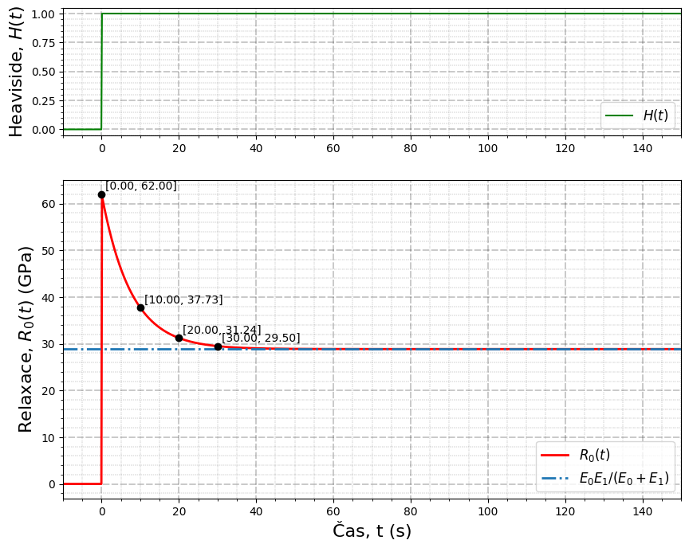

```python
fig, axs = plt.subplots(2, 1, figsize=(10,8), gridspec_kw={'height_ratios': [1, 2.5]})

axs[0].plot(t, H, 'g', label='$H(t)$')
axs[0].set_ylabel('Heaviside, $H(t)$', fontsize=16)

axs[1].plot(t, R_0, 'r', lw=2, label='$R_0(t)$')
axs[1].axhline(R_0_of_interest[-1], lw=2, ls='-.', label='$E_0 E_1 / (E_0 + E_1)$')
axs[1].set_ylabel('Relaxace, $R_0(t)$ (GPa)', fontsize=16)
axs[1].set_xlabel('Čas, t (s)', fontsize=16)

for time, relaxation in zip(times_of_interest[:-1], R_0_of_interest[:-1]):
    plot_point_of_interest(time, relaxation, axs[1], 1, 0.5, 'left', 'bottom')

for i in [0, 1]:
    axs[i].grid(which="major", linestyle=(10, (20, 6)), color='black', lw=0.3)
    axs[i].minorticks_on()
    axs[i].grid(which="minor", linestyle=(0, (1, 3)), color='black', lw=0.3)
    axs[i].legend(loc="lower right", fontsize=12)
    axs[i].set_xlim(t.min(), t.max())

plt.show()
```

## Porovnání $R_0(t) = \frac{1}{J_0(t)}$

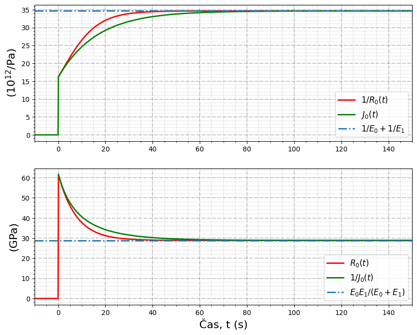

```python
fig, axs = plt.subplots(2, 1, figsize=(10,8))

axs[0].plot(t[R_0!=0], 1/R_0[R_0!=0] * 10**3, 'r', lw=2, label='$1/R_0(t)$')
axs[0].plot(t, J_0, 'g', lw=2, label='$J_0(t)$')
axs[0].axhline(J_0_of_interest[-1], lw=2, ls='-.', label='$1/E_0 + 1/E_1$')
axs[0].set_ylabel('($10^{12}$/Pa)', fontsize=16)

axs[1].plot(t, R_0, 'r', lw=2, label='$R_0(t)$')
axs[1].plot(t[J_0!=0], 1/J_0[J_0!=0] * 10**3, 'g', lw=2, label='$1/J_0(t)$')
axs[1].axhline(R_0_of_interest[-1], lw=2, ls='-.', label='$E_0 E_1 / (E_0 + E_1)$')
axs[1].set_ylabel('(GPa)', fontsize=16)
axs[1].set_xlabel('Čas, t (s)', fontsize=16)

for i in [0, 1]:
    axs[i].grid(which="major", linestyle=(10, (20, 6)), color='black', lw=0.3)
    axs[i].minorticks_on()
    axs[i].grid(which="minor", linestyle=(0, (1, 3)), color='black', lw=0.3)
    axs[i].legend(loc="lower right", fontsize=12)
    axs[i].set_xlim(t.min(), t.max())
```

Z grafu je patrné, že vztah

$$ R_0(t) = \frac{1}{J_0(t)} \tag{74.0} \label{eq:R_is_J} $$

platí pouze pro $t = 0 \, \mathrm{s}$ a pro $t \rightarrow +\infty$.

Ověříme dosazením pro $t = 0 \, \mathrm{s}$ do vztahu \eqref{eq:funkce_poddajnosti}

$$ J_0(0) = \left( \frac{1}{E_0} + \frac{1}{E_1} \left[1 - \exp{\left(-\frac{0}{\tau_1}\right)} \right] \right) H(0) = \left( \frac{1}{E_0} + \frac{1}{E_1} \left[1 - \exp{0} \right] \right) \cdot 1 = \frac{1}{E_0}, \tag{75.0} \label{eq:J0_0} $$

a do \eqref{eq:relaxacni_funkce}

$$ R_0(0) = H(0) \frac{E_0}{E_0 + E_1} \left( E_1 + E_0 \exp{\left(-\frac{E_0+E_1}{\eta_1} \cdot 0 \right)} \right) = 1 \cdot \frac{E_0}{E_0 + E_1} \left( E_1 + E_0 \exp{(0)} \right) = \frac{E_0(E_0 + E_1)}{E_0 + E_1} = E_0. \tag{76.0} \label{eq:R0_0} $$

To samé provedeme pro $t \rightarrow +\infty$.

$$ J_0(t \rightarrow +\infty) = \left( \frac{1}{E_0} + \frac{1}{E_1} \left[1 - \exp{\left(-\frac{t \rightarrow +\infty}{\tau_1}\right)} \right] \right) H(t \rightarrow +\infty) = \left( \frac{1}{E_0} + \frac{1}{E_1} \left[1 - 0 \right] \right) \cdot 1 = \frac{1}{E_0} + \frac{1}{E_1} = \frac{E_0+E_1}{E_0 E_1}, \tag{77.0} \label{eq:J0_oo} $$

$$ R_0(t \rightarrow +\infty) = H(t \rightarrow +\infty) \frac{E_0}{E_0 + E_1} \left( E_1 + E_0 \exp{\left(-\frac{E_0+E_1}{\eta_1} \cdot t \rightarrow +\infty \right)} \right) = 1 \cdot \frac{E_0}{E_0 + E_1} \left( E_1\right) = \frac{E_0 E_1}{E_0 + E_1}. \tag{78.0} \label{eq:R0_oo} $$

Z výsledků je zřejmé, že vztah \eqref{eq:R_is_J} platí pro $t = 0 \, \mathrm{s}$ a pro $t \rightarrow +\infty$.

## Popis vývoje deformace při lineární rostoucím napětí

Předpokládejme lineární růst napětí z nulové hodnoty v čase $t_0 = 0 \, \mathrm{s}$ až do hodnoty $\sigma(t_1) = \hat{\sigma}$.

Funkci napětí lze tedy vyjádřit vztahem

$$ \sigma(t) = \frac{\hat{\sigma}}{t_1}t, \tag{79.0} $$

a její derivaci

$$ \dot{\sigma}(t) = \frac{\hat{\sigma}}{t_1}. \tag{80.0} $$

V tomto případě se poměrná deformace vypočítá podle vztahu

$$ \varepsilon(t) = \int_{t_0}^t J(t, t') \dot{\sigma}(t') \mathrm{d}t \tag{81.0} \label{eq:pomerna_deformace} $$

Dosazením za $J(t,t')$ a $\dot{\sigma}(t)$ dostaneme rovnici

$$ \varepsilon(t) = \int_0^t \left( \frac{1}{E_0} + \frac{1}{E_1} \left[ 1 - \exp \left( -\frac{t-t'}{\tau_1} \right) \right] \right) \frac{\hat{\sigma}}{t_1} \mathrm{d}t'. \tag{81.0} $$

Integrací získáme

$$ \varepsilon(t) = \frac{\hat{\sigma}}{t_1} \left[ \frac{1}{E_0} [t']_0^t + \frac{1}{E_1} [t']_0^t - \frac{1}{E_1} \tau_1 \exp \left( -\frac{t}{\tau_1} \right) \left[ \exp{ \left( \frac{t'}{\tau_1} \right) - 1} \right]_0^t \right]. \tag{81.2} $$

Dosazením dostaneme výraz pro poměrnou deformaci

$$ \varepsilon(t) = \frac{\hat{\sigma}}{t_1} \left[ \frac{t}{E_0} + \frac{t}{E_1} - \frac{\tau_1}{E_1} + \frac{\tau_1}{E_1} \exp{\left( \frac{-t}{\tau_1} \right)} \right]. \tag{81.3} $$

Při extrémně rychlém zatížení ($t \rightarrow 0^+)$ se deformuje pouze pružina, vztah pro deformaci tedy lze napsat jako

$$ \varepsilon = \frac{\hat{\sigma}}{E_0}. \tag{82.0} $$

$$ \varepsilon = \hat{\sigma}\left( \frac{1}{E_0} + \frac{1}{E_1} \right). \tag{83.0} $$

```python
SIGMA_HAT = 8  # (GPa)
def stress(t: int| float | np.ndarray, t_1: int | float) -> int | float | np.ndarray:
    return (SIGMA_HAT / t_1) * t

def strain(t: int | float | np.ndarray, t_1: int | float) -> int | float | np.ndarray:
    return (SIGMA_HAT / t_1) * (t/E_0 + t/E_1 - TAU_1/E_1 + TAU_1/E_1 * np.exp(-t/TAU_1))
```

```python
t_1a = 10
t_1b = 20
t_1c = 40


t_a = np.linspace(0, t_1a, 100)
t_b = np.linspace(0, t_1b, 100)
t_c = np.linspace(0, t_1c, 100)

sigma_a = stress(t_a, t_1a)
sigma_b = stress(t_b, t_1b)
sigma_c = stress(t_c, t_1c)

strain_a = strain(t_a, t_1a)
strain_b = strain(t_b, t_1b)
strain_c = strain(t_c, t_1c)

strain_0 = SIGMA_HAT / E_0  # extremne rychle zatizeni
strain_oo = SIGMA_HAT * ( 1/E_0 + 1/E_1)  # extremne pomale zatizeni
```

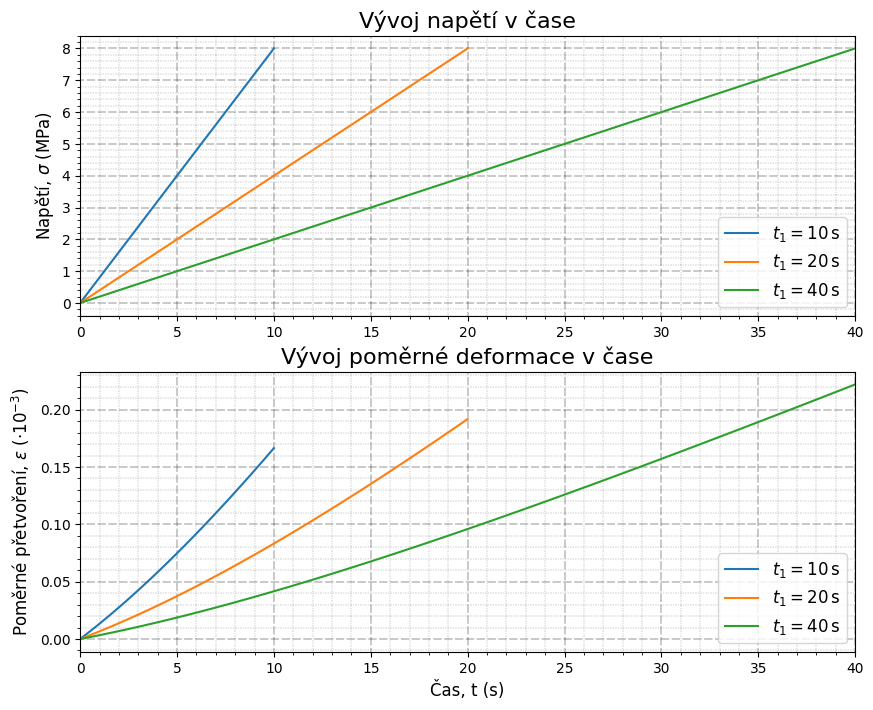

```python
fig, axs = plt.subplots(2, 1, figsize=(10,8))

axs[0].plot(t_a, sigma_a, label='$t_1 = 10 \, \mathrm{s}$')
axs[0].plot(t_b, sigma_b, label='$t_1 = 20 \, \mathrm{s}$')
axs[0].plot(t_c, sigma_c, label='$t_1 = 40 \, \mathrm{s}$')
axs[0].set_ylabel('Napětí, $\sigma$ (MPa)', fontsize=12)
axs[0].set_title('Vývoj napětí v čase', fontsize=16)

axs[1].plot(t_a, strain_a, label='$t_1 = 10 \, \mathrm{s}$')
axs[1].plot(t_b, strain_b, label='$t_1 = 20 \, \mathrm{s}$')
axs[1].plot(t_c, strain_c, label='$t_1 = 40 \, \mathrm{s}$')
axs[1].set_ylabel('Poměrné přetvoření, $\\varepsilon$ ($\cdot 10^{-3}$)', fontsize=12)
axs[1].set_xlabel('Čas, t (s)', fontsize=12)
axs[1].set_title('Vývoj poměrné deformace v čase', fontsize=16)

for i in [0, 1]:
    axs[i].grid(which="major", linestyle=(10, (20, 6)), color='black', lw=0.3)
    axs[i].minorticks_on()
    axs[i].grid(which="minor", linestyle=(0, (1, 3)), color='black', lw=0.3)
    axs[i].legend(loc="lower right", fontsize=12)
    axs[i].set_xlim(0, t_1c)
```

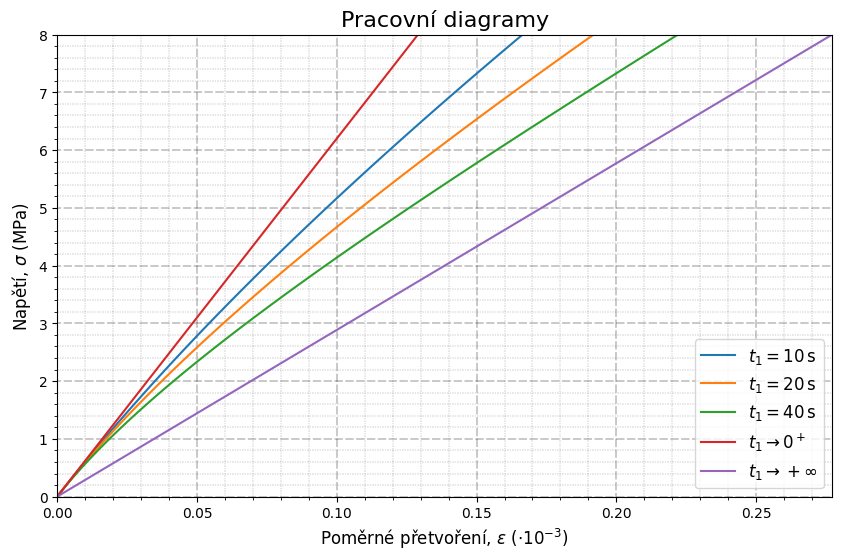

```python
fig = plt.figure(figsize=(10,6))

plt.plot(strain_a, sigma_a, label='$t_1 = 10 \, \mathrm{s}$')
plt.plot(strain_b, sigma_b, label='$t_1 = 20 \, \mathrm{s}$')
plt.plot(strain_c, sigma_c, label='$t_1 = 40 \, \mathrm{s}$')
plt.plot([0, strain_0], [0, SIGMA_HAT], label=r'$t_1 \rightarrow 0^+$')
plt.plot([0, strain_oo], [0, SIGMA_HAT], label=r'$t_1 \rightarrow + \infty$')

plt.grid(which="major", linestyle=(10, (20, 6)), color='black', lw=0.3)
plt.minorticks_on()
plt.grid(which="minor", linestyle=(0, (1, 3)), color='black', lw=0.3)
plt.legend(loc="lower right", fontsize=12)
plt.title('Pracovní diagramy', fontsize=16)
plt.ylabel('Napětí, $\sigma$ (MPa)', fontsize=12)
plt.xlabel('Poměrné přetvoření, $\\varepsilon$ ($\cdot 10^{-3}$)', fontsize=12)
plt.xlim(0, strain_oo)
plt.ylim(0, SIGMA_HAT)
plt.show()
```